# Analiza skupień

Morozov Andrii

25 10 2020

## **CEL PROJEKTU i HIPOTEZY BADAWCZE**

**Celem projektu** jest sprawdzenie na danych “realnych” metod grupowania podzialowego oraz hierarchicznego.  
Byla podjeta proba wyliczyc optymalna liczbe podzialow oraz liczbe skupien w oparciu o indeksy G1, G2, G3 oraz S. (funkcja BI)

**Hipoteza badawcza**: wyniki grupowania poszczegolnych metod **NIE** roznia sie istotnie.

## **Metody grupowania wykorzystane w projekcie oraz inne podstawy**

Dla **grupowania podzialowego**: metoda k-srednich oraz k-medoid.  
Dla metody **k-medoid** odleglosci byly liczone metodami Euklidesa oraz “manhattan”.

Dla **grupowania hierarchicznego** byla wykorzystana metoda **“ward.D”**,**“complete”** oraz **“average”**.  
Odleglosci byly liczone metodami: Euklidesa, “manhattan” oraz Minkowskiego.

**Normalizacja** danych byla typu “n1”, czyli **((x-mean)/sd)**.

**Indeksy G1, G2, G3 oraz S** byly liczone dla kazdego rodzaju metryk.

## ** NIEZBEDNE PAKIETY ORAZ FUNKCJE **

```r
library(clusterSim)
library(ggpubr)
library(factoextra)
library(fpc)

setwd("C:/Users/An/Desktop/SAD")
df <- read.csv("CS_GO.csv", sep = ";", row.names = "obs")

N = 50
cnames <- c("index G1","index G2","index S","index G3")
rnames <- c(2:N)

#===== BEST INDEX =====

BI <- function(choi, data, .dist, choi.dist = "EU") {
  indG1 <- NULL
  indG2 <- NULL
  indG3 <- NULL
  indS <- NULL
  final_t <- NULL
  for (j in 2:N){
    if (choi == "H") {
      temp <- cutree(data, j)
      indG1[j-1] <- index.G1(df, cl = temp, d = .dist, centrotypes = "medoids")
      indG2[j-1] <- index.G2(.dist, cl = temp)
      indG3[j-1] <- index.G3(.dist, cl = temp)
      indS[j-1] <- index.S(.dist, cl= temp)
    } else if(choi == "PP") {
      if (choi.dist == "EU") {
      temp <- pam(data, i, metric = "euclidean", stand = FALSE)
      indG1[j-1] <- index.G1(data, cl = temp$clustering, d = .dist, centrotypes = "medoids")
      indG2[j-1] <- index.G2(.dist, cl = temp$clustering)
      indG3[j-1] <- index.G3(.dist, cl = temp$clustering)
      indS[j-1] <- index.S(.dist, cl= temp$clustering)
      } else {
        temp <- pam(data, i, metric = "manhattan", stand = FALSE)
        indG1[j-1] <- index.G1(data, cl = temp$clustering, d = .dist, centrotypes = "medoids")
        indG2[j-1] <- index.G2(.dist, cl = temp$clustering)
        indG3[j-1] <- index.G3(.dist, cl = temp$clustering)
        indS[j-1] <- index.S(.dist, cl= temp$clustering)
      }
    } else if(choi == "PK") {
        temp <- kmeans(data, i, nstart = 50, iter.max = 50 )
        indG1[j-1] <- index.G1(data, cl = temp$cluster, d = .dist, centrotypes = "centroids")
        indG2[j-1] <- index.G2(.dist, cl = temp$cluster)
        indG3[j-1] <- index.G3(.dist, cl = temp$cluster)
        indS[j-1] <- index.S(.dist, cl= temp$cluster)
    } else {
      print("prosze podac wlasciwe grupowanie H lub PP lub PK !")
      break
    }
  }
  final_t <- list(indG1,indG2,indS,indG3)
  return(final_t)
}
```

## **OPIS DANYCH**

Dane statystyczne były pobrane ze strony internetowej **https://www.hltv.org/**.  
Był wybrany turniej **„DreamHack Masters Spring 2020 – Europe”** i pobrane wyniki sportowców w fazie grupowej za każdą zagraną „kartę”.  
Wszystkie mecze były do 2 zwycięstw, czyli maksymalnie mogły być zagrane 3 „karty” w jednym meczu.  
Dane były kopiowane ręcznie dla każdego gracza bezpośrednio ze strony internetowej do pliku EXCEL.

**Zmienne**:  
• Rating_2.0 – wyliczony indywidualnie dla każdego sportowca przez organizacje **„HLTV”** wskaźnik reprezentujący kumulację wyników gracza za jedną „kartę”. Organizacja „HLTV” **NIE** podaje wzoru do obliczenia danego wskaźnika.  
• Kills – liczba „zabójstw” zrobionych przez gracza za jedną „kartę”.  
• Assists - liczba „pomocy” zrobionych przez gracza za jedną „kartę”. Aby uzyskać „pomóc” „gracz 1” musi zadać co najmniej 41 punktów obrażeń lub więcej, a następnie przeciwnik zostaje zabity przez „gracza 2”.  
• Deaths – liczba „śmierci” gracza za „kartę”. Każdy gracz na początku każdej rundy ma 100 punktów zdrowotnych, jeżeli liczba punktów zdrowotnych spadnie do 0 następuje „śmierć” gracza.  
• KAST - mierzy odsetek rund, w których gracz bierze udział zabijając przeciwnika, pomagając sojusznikowi lub przeżywając rundę.  
• ADR – sumaryczna liczba „obrażeń” zadanych graczem drużynie przeciwnika podzielona przez liczbę rund zagranych za „kartę”.  
• Impact – wskaźnik liczony indywidualni dla każdego sportowca po zagranej „karcie”. Organizacja „HLTV” **NIE** podaje dokładnego wzoru do obliczenia danego wskaźnika. Mierzy „wpływ” gracza na „karcie” oparty o liczbę „multi-zabójstw”, zrobionych “zabójstw-otwarć” (pierwsze zabójstwo w rundzie), wygranych sytuacji gdy gracz zostaje sam przeciwko drużynie przeciwnika, itd.  
• AGE – aktualny wiek sportowca.

## WSTEPNA ANALIZA DANYCH

Plik **“CS_GO.csf”** bedzie dolaczony do sprawozdania. Na wstepie mamy 520 obserwacji. Kazda obserwacja to wyniki zawarte w zmiennych opisanych wyzej dla jednego gracza.

```
##         Rating  Kills Assists Deaths   KAST    ADR Impact    Age
## Rating   1.000  0.711   0.159 -0.443  0.794  0.855  0.877 -0.085
## Kills    0.711  1.000   0.209  0.205  0.484  0.711  0.673 -0.097
## Assists  0.159  0.209   1.000  0.217  0.248  0.218  0.151  0.068
## Deaths  -0.443  0.205   0.217  1.000 -0.422 -0.196 -0.270  0.062
## KAST     0.794  0.484   0.248 -0.422  1.000  0.564  0.499 -0.079
## ADR      0.855  0.711   0.218 -0.196  0.564  1.000  0.790 -0.060
## Impact   0.877  0.673   0.151 -0.270  0.499  0.790  1.000 -0.031
## Age     -0.085 -0.097   0.068  0.062 -0.079 -0.060 -0.031  1.000
```

```
## [1] 29.81684 34.20391 53.81223 25.73119 15.59663 24.74424 42.64941 14.50277
```

Macierz korelacji nie wykazala wartosci powyzej 0.9 -> brak efektu wspolliniowosci.  
Wsp.zmiennosci na dole dla kazdej zmiennej wynosi >10% -> brak “quazi” stalych zmiennych.

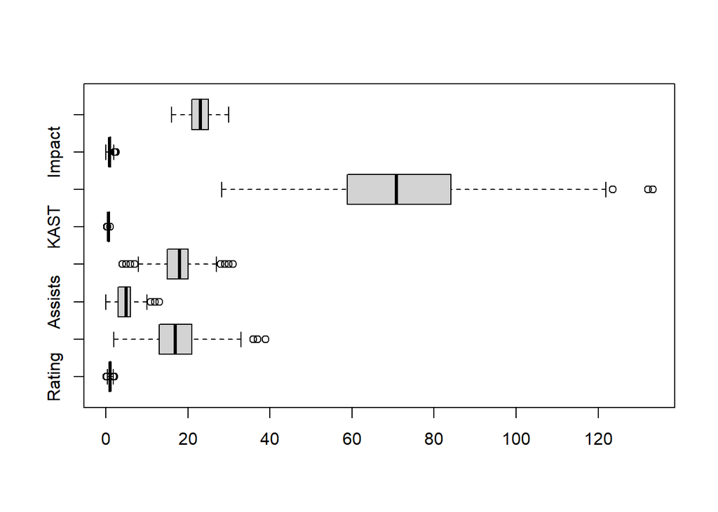

```r
boxplot(df, horizontal = TRUE)
```

```r
summary(df)
```

```
##      Rating         Kills         Assists           Deaths           KAST
##  Min.   :0.19   Min.   : 2.0   Min.   : 0.000   Min.   : 4.00   Min.   :0.320
##  1st Qu.:0.84   1st Qu.:13.0   1st Qu.: 3.000   1st Qu.:15.00   1st Qu.:0.630
##  Median :1.03   Median :17.0   Median : 5.000   Median :18.00   Median :0.700
##  Mean   :1.05   Mean   :17.8   Mean   : 4.879   Mean   :17.82   Mean   :0.698
##  3rd Qu.:1.23   3rd Qu.:21.0   3rd Qu.: 6.000   3rd Qu.:20.00   3rd Qu.:0.770
##  Max.   :2.16   Max.   :39.0   Max.   :13.000   Max.   :31.00   Max.   :1.000
##       ADR             Impact           Age
##  Min.   : 28.20   Min.   :0.000   Min.   :16.00
##  1st Qu.: 58.98   1st Qu.:0.730   1st Qu.:21.00
##  Median : 70.80   Median :0.950   Median :23.00
##  Mean   : 72.24   Mean   :1.001   Mean   :22.96
##  3rd Qu.: 84.05   3rd Qu.:1.242   3rd Qu.:25.00
##  Max.   :133.30   Max.   :2.550   Max.   :30.00
```

Na wykresie widac, ze dane pochodza z roznych rozkladow oraz widac spora liczbe “outlierow”.  
Statystyki opisowe rowniez to potwierdzaja.

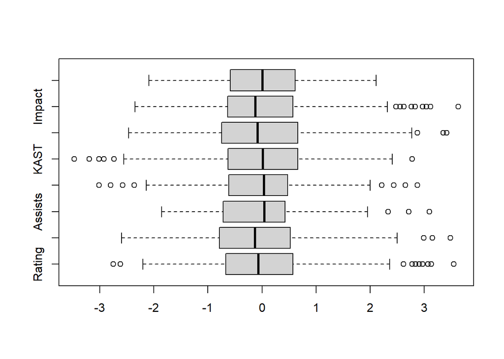

```
##      Rating            Kills            Assists             Deaths
##  Min.   :-2.7470   Min.   :-2.5951   Min.   :-1.85831   Min.   :-3.01413
##  1st Qu.:-0.6709   1st Qu.:-0.7882   1st Qu.:-0.71564   1st Qu.:-0.61557
##  Median :-0.0640   Median :-0.1311   Median : 0.04615   Median : 0.03858
##  Mean   : 0.0000   Mean   : 0.0000   Mean   : 0.00000   Mean   : 0.00000
##  3rd Qu.: 0.5748   3rd Qu.: 0.5260   3rd Qu.: 0.42704   3rd Qu.: 0.47468
##  Max.   : 3.5452   Max.   : 3.4828   Max.   : 3.09328   Max.   : 2.87324
##       KAST               ADR               Impact             Age
##  Min.   :-3.47213   Min.   :-2.46370   Min.   :-2.3447   Min.   :-2.09092
##  1st Qu.:-0.62447   1st Qu.:-0.74200   1st Qu.:-0.6343   1st Qu.:-0.58957
##  Median : 0.01855   Median :-0.08045   Median :-0.1188   Median : 0.01097
##  Mean   : 0.00000   Mean   : 0.00000   Mean   : 0.0000   Mean   : 0.00000
##  3rd Qu.: 0.66157   3rd Qu.: 0.66082   3rd Qu.: 0.5665   3rd Qu.: 0.61151
##  Max.   : 2.77434   Max.   : 3.41610   Max.   : 3.6300   Max.   : 2.11286
```

Na wykresie widac, ze “porownywalnosc” danych po **standaryzacji** nieco poprawila sie.  
Wykres pudelkowy pokazuje, ze poza granicami **3-sigm** znajduje sie jedna, maksymalnie 3 obserwacji.  
Nadal sa “outliery”, ale dla zbioru danych z 520 obserwacjami ich liczba jest znikoma.  
Zbior danych nadaje sie dla dalszej analizy.

## **LICZBA PODZIALOW** oraz **SKUPIEN, metoda “ward.D”**

Optymalna liczba podzialow bedzie liczona dla metod opisanych wyzej z uwzglednieniem roznych metryk.  
Teoretycznie dla 520 obserwacji, liczba skupien oraz podzialow wynosi 519 jednostek.  
Ze wzgledu na czasochlonnosc obliczen i brak takiej mocy obliczeniowej, optymalna liczba skupien oraz podzialow bedzie ustalona dla maksymalnie 50 jednostek.  
Dla kazdej z metod oraz metryk bedzie stworzona tablica, w kolumnach ktorej beda wartosci **indeksow G1, G2, S oraz G3** odpowiednio dla liczby klasterow od 2 do 50.  
Dla **indeksow G1 G2 S** wybieramy maksymalna wartosc, dla **indeksu G3** minimalna.

Dla metody podzialowej, k-srednich, **metryka Euklidesa**.

```
##    index G1  index G2   index S  index G3
## 2  118.2136 0.7144233 0.1764671 0.3736809
## 3  118.2321 0.7138418 0.1753648 0.3733294
## 4  118.2136 0.7144233 0.1764671 0.3736809
## 5  118.2136 0.7144233 0.1764671 0.3736809
## 6  118.2136 0.7144233 0.1764671 0.3736809
## 7  118.2321 0.7138418 0.1753648 0.3733294
## 8  118.2136 0.7144233 0.1764671 0.3736809
## 9  118.0600 0.7136391 0.1760338 0.3737742
## 10 118.2293 0.7115534 0.1758038 0.3738597
## 11 118.0093 0.7111344 0.1749207 0.3738862
## 12 118.2136 0.7144233 0.1764671 0.3736809
## 13 118.2136 0.7144233 0.1764671 0.3736809
## 14 118.2136 0.7144233 0.1764671 0.3736809
## 15 118.2321 0.7138418 0.1753648 0.3733294
```

[output cut: 35 more lines]

Dla metody podzialowej, k-srednich, **metryka “manhattan”**.

```
##    index G1  index G2   index S  index G3
## 2  118.2321 0.7067943 0.1739111 0.3492710
## 3  118.2136 0.7047359 0.1744702 0.3503742
## 4  118.2293 0.7041928 0.1740794 0.3499620
## 5  118.1577 0.7035709 0.1736669 0.3505315
## 6  118.1100 0.7013763 0.1748023 0.3510688
## 7  118.2136 0.7047359 0.1744702 0.3503742
## 8  118.2136 0.7047359 0.1744702 0.3503742
## 9  118.2136 0.7047359 0.1744702 0.3503742
## 10 118.1403 0.7045731 0.1734078 0.3501435
## 11 118.2321 0.7067943 0.1739111 0.3492710
## 12 118.2321 0.7067943 0.1739111 0.3492710
## 13 118.0405 0.7035324 0.1743052 0.3509156
## 14 118.2136 0.7047359 0.1744702 0.3503742
## 15 118.2136 0.7047359 0.1744702 0.3503742
```

[output cut: 35 more lines]

Dla metody podzialowej, k-srednich, **metryka Minkowskiego**.

```
##    index G1  index G2   index S  index G3
## 2  118.1403 0.7017556 0.1715501 0.3559300
## 3  118.2136 0.7034681 0.1728475 0.3691674
## 4  118.1403 0.7017556 0.1715501 0.3559300
## 5  118.2136 0.7034681 0.1728475 0.3691674
## 6  118.2136 0.7034681 0.1728475 0.3691674
## 7  118.2136 0.7034681 0.1728475 0.3691674
## 8  118.2136 0.7034681 0.1728475 0.3691674
## 9  118.2321 0.7007862 0.1709746 0.3670797
## 10 118.2321 0.7007862 0.1709746 0.3670797
## 11 118.0488 0.6996100 0.1720425 0.3697554
## 12 118.2136 0.7034681 0.1728475 0.3691674
## 13 118.2136 0.7034681 0.1728475 0.3691674
## 14 118.1442 0.6978698 0.1711791 0.3678567
## 15 118.2321 0.7007862 0.1709746 0.3670797
```

[output cut: 35 more lines]

Dla metody podzialowej, k-medoid, **metryka Euklidesa**.

```
##    index G1  index G2   index S index G3
## 2  111.2354 0.7060264 0.1523765 0.329119
## 3  111.2354 0.7060264 0.1523765 0.329119
## 4  111.2354 0.7060264 0.1523765 0.329119
## 5  111.2354 0.7060264 0.1523765 0.329119
## 6  111.2354 0.7060264 0.1523765 0.329119
## 7  111.2354 0.7060264 0.1523765 0.329119
## 8  111.2354 0.7060264 0.1523765 0.329119
## 9  111.2354 0.7060264 0.1523765 0.329119
## 10 111.2354 0.7060264 0.1523765 0.329119
## 11 111.2354 0.7060264 0.1523765 0.329119
## 12 111.2354 0.7060264 0.1523765 0.329119
## 13 111.2354 0.7060264 0.1523765 0.329119
## 14 111.2354 0.7060264 0.1523765 0.329119
## 15 111.2354 0.7060264 0.1523765 0.329119
```

[output cut: 35 more lines]

Dla metody podzialowej, k-medoid, **metryka “manhattan”**.

```
##    index G1  index G2   index S  index G3
## 2  101.7721 0.6900125 0.1576738 0.3256397
## 3  101.7721 0.6900125 0.1576738 0.3256397
## 4  101.7721 0.6900125 0.1576738 0.3256397
## 5  101.7721 0.6900125 0.1576738 0.3256397
## 6  101.7721 0.6900125 0.1576738 0.3256397
## 7  101.7721 0.6900125 0.1576738 0.3256397
## 8  101.7721 0.6900125 0.1576738 0.3256397
## 9  101.7721 0.6900125 0.1576738 0.3256397
## 10 101.7721 0.6900125 0.1576738 0.3256397
## 11 101.7721 0.6900125 0.1576738 0.3256397
## 12 101.7721 0.6900125 0.1576738 0.3256397
## 13 101.7721 0.6900125 0.1576738 0.3256397
## 14 101.7721 0.6900125 0.1576738 0.3256397
## 15 101.7721 0.6900125 0.1576738 0.3256397
```

[output cut: 35 more lines]

Dla metody hierarchicznej, typu **ward.D**, **metryka Euklidesa**.

```
##     index G1   index G2   index S  index G3
## 2  248.28184 -1.4131077 0.2484625 0.3440002
## 3  169.93197 -1.6312480 0.1434917 0.3354512
## 4  142.66270 -1.9519056 0.1355473 0.3438374
## 5  198.60062 -2.0321876 0.1382631 0.3638629
## 6  175.57908 -2.2581273 0.1327768 0.3555975
## 7  150.09335  0.6149845 0.1376777 0.3369210
## 8  127.27142  0.6248786 0.1226178 0.3248253
## 9  127.93484  0.6547611 0.1218082 0.3132549
## 10 126.62980  0.6773901 0.1259916 0.3682351
## 11 107.88113  0.6993710 0.1304977 0.3594250
## 12  99.61513  0.7068568 0.1208547 0.3544733
## 13  93.66094  0.7184843 0.1212222 0.3497297
## 14  85.53142  0.7232817 0.1212407 0.3462420
## 15  77.69549  0.7295687 0.1197830 0.3409869
```

[output cut: 35 more lines]

Dla metody hierarchicznej, typu **ward.D**, **metryka “manhattan”**.

```
##     index G1   index G2   index S  index G3
## 2  242.77203 -1.4322083 0.2689698 0.3057503
## 3  304.49849 -1.5617032 0.1721029 0.2844746
## 4  244.39696 -1.8000530 0.1373707 0.2779775
## 5  179.02024 -2.0832110 0.1297305 0.2633748
## 6  175.67087 -2.2423051 0.1483931 0.3149765
## 7  175.31445  0.6459208 0.1521711 0.3027306
## 8  155.79261  0.6777178 0.1514003 0.3493457
## 9  137.81172  0.6857419 0.1385430 0.3421704
## 10 129.78260  0.6917934 0.1327270 0.3365395
## 11 119.27482  0.7141107 0.1365054 0.3617423
## 12 110.48592  0.7346936 0.1413430 0.3535414
## 13 103.01360  0.7414830 0.1244230 0.3487432
## 14  90.66384  0.7398542 0.1172171 0.3472003
## 15  83.94554  0.7424608 0.1188918 0.3412740
```

[output cut: 35 more lines]

Dla metody hierarchicznej, typu **ward.D**, **metryka Minkowskiego**.

```
##     index G1   index G2   index S  index G3
## 2  218.79036 -1.4524193 0.2194765 0.3496218
## 3  114.98138 -1.7001880 0.1096432 0.3400194
## 4  131.97302 -1.8896210 0.1141959 0.3395201
## 5  142.30500 -2.4129176 0.1206813 0.3416089
## 6  158.59290 -2.5255940 0.1282528 0.3562699
## 7  131.84776  0.5759417 0.1227425 0.3486544
## 8  118.91536  0.6076938 0.1178873 0.3360105
## 9  115.80406  0.6172311 0.1105207 0.3276204
## 10 103.71286  0.6446168 0.1154956 0.3773359
## 11  95.67944  0.6856739 0.1239631 0.3588944
## 12  88.91528  0.6962177 0.1200401 0.3519083
## 13  85.51835  0.7011827 0.1169501 0.3721853
## 14  80.48653  0.7118771 0.1158493 0.3666199
## 15  73.12955  0.7100900 0.1100092 0.3623232
```

[output cut: 35 more lines]

## **GRAFICZNA PREZENTACJA WYNIKOW dla metod podzialu**

Z tablic wyzej widzimy, ze dla grupowania podzialowego **indeksy G1, G2, G3 i S** nie maja istotnego sensu. Wiecej o tym bedzie w sekcji **WNIOSKI**  
Pozostaje metoda “ekspercka”, czyli “na oko”. Porownania kazdego grupowania bedzie w sekcji **WYBOR OPTYMALNYCH GRUPOWAN dla metody podzialowej oraz hierarchicznej**  
Dla **metody k-means** ustawiamy liczbe podzialow = 2, 3 oraz 4.

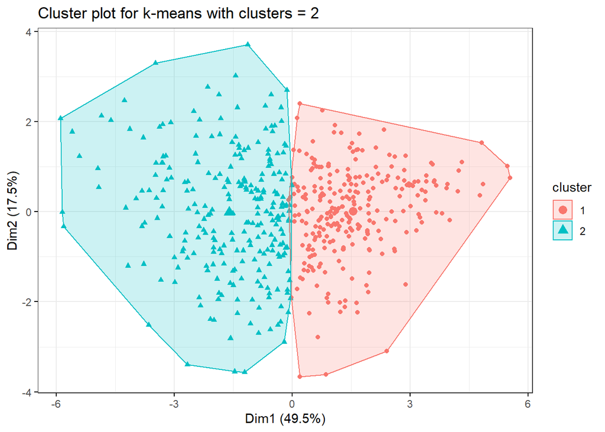

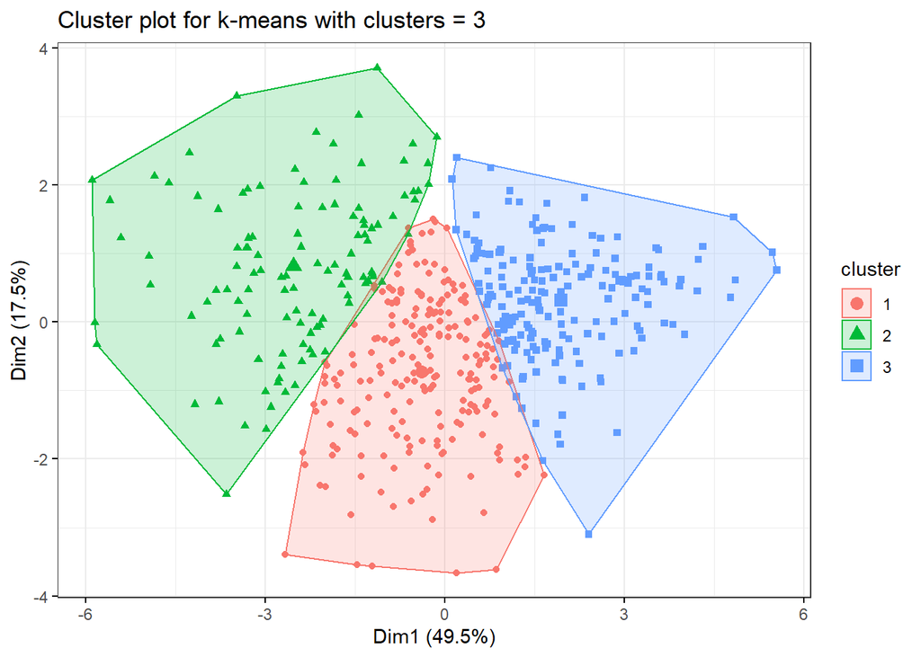

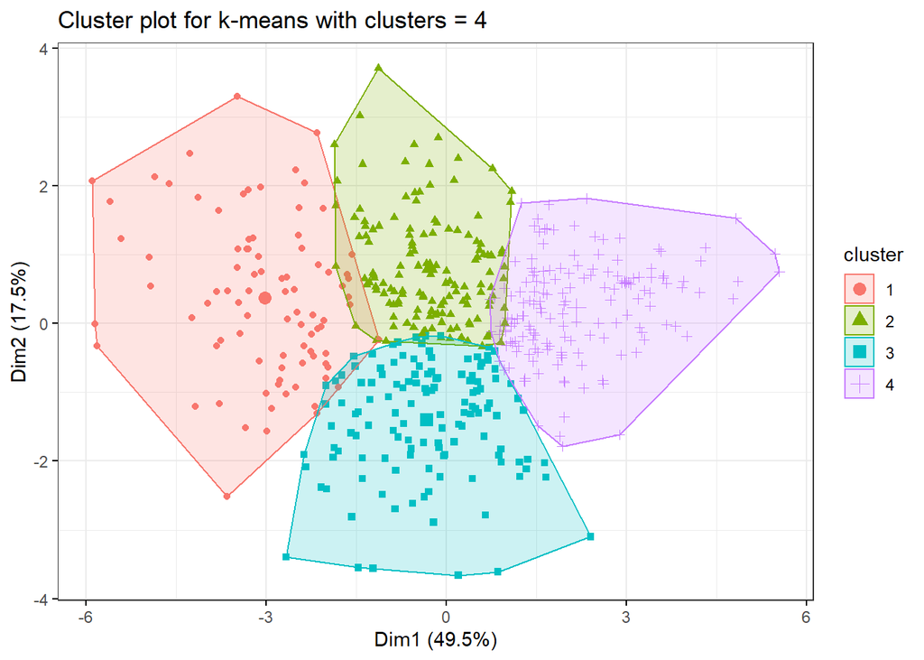

To samo wynika z tablic dla **metody k-medoid**  
Ustawimy z gory liczbe przedzialow = 2, 3 oraz 4.

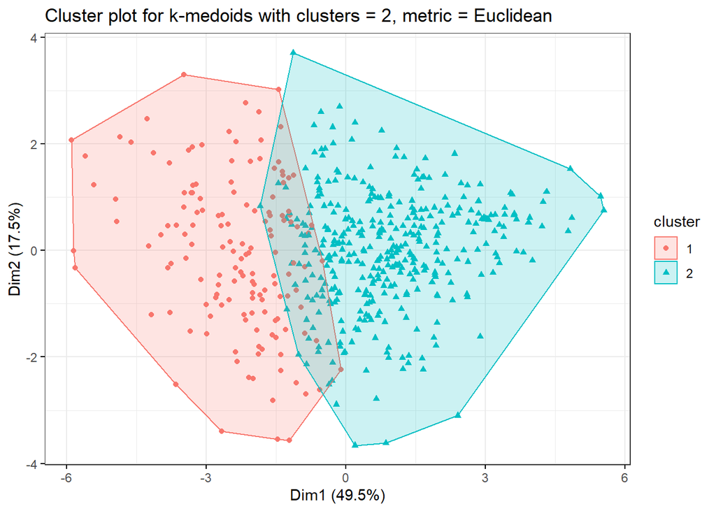

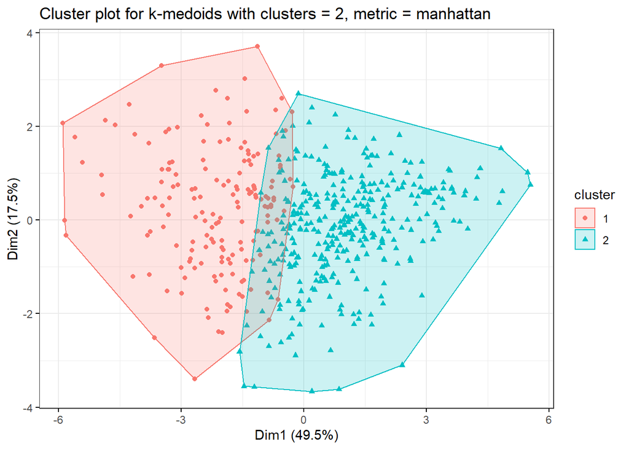

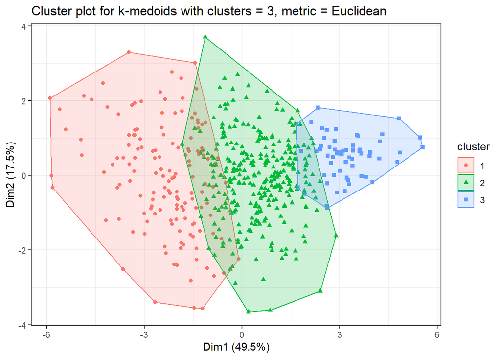

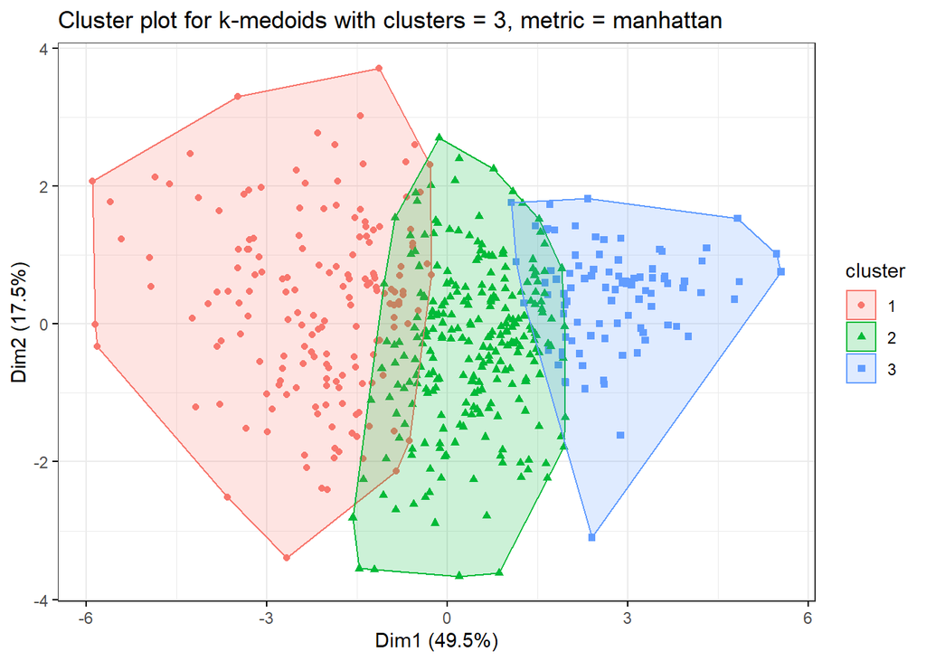

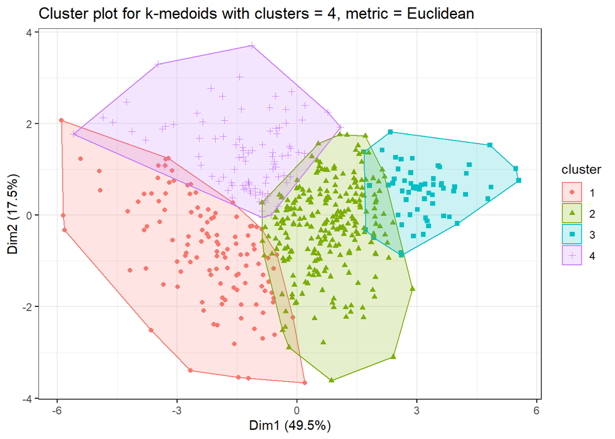

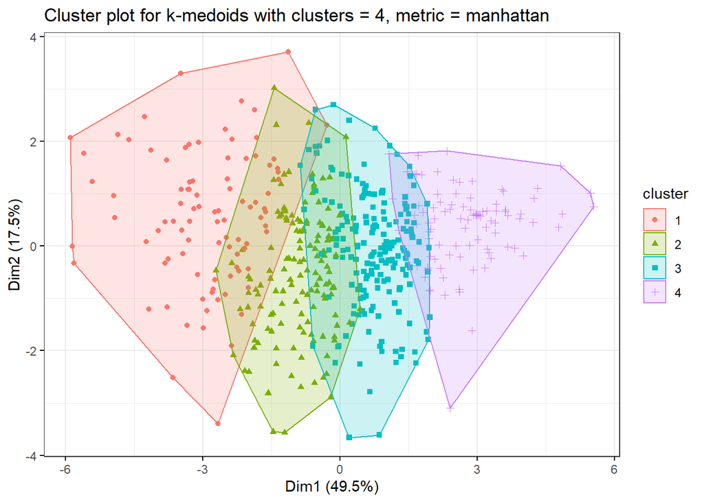

Z wykresow wyzej widac, ze dla liczby podzialow = 3, w metryce **Euklidesa oraz manhattan** i dla liczby podzialow = 4 w metryce **manhattan** grupy zostaly mocno pomieszane.  
Na razie “najlepiej” wyglada podzial **k-medoids, metryka Euklidesa**.  
## **GRAFICZNA PREZENTACJA WYNIKOW dla metody hierarchicznej, metoda “ward.D”**

Z tablic dla **metody hierarchicznej** typu **ward.D** widac nastepujaca tendencje:  
1.**indeksy G1** ma najwieksza wartosc dla liczby skupien = 2 w metryce **Euklidesa oraz Minkowskiego**, dla **metryki manhattan** optymalna liczba skupien = 3.  
2.**indeksy G2** rosnie wraz z wzrostem liczby podzialow.  
3.**indeks G3** jest quazi" staly.  
4.**indeks S** jest optymalny dla liczby skupien = 2 dla kazdej z metryk.

Ze wzgledu na powyzsze sprawdzimy dendrogramy dla liczby skupien = 2 oraz 3.  
Najpierw bedzie przedstawiony dendrogram dla liczby skupien = 2 dla kazdej z metryk.

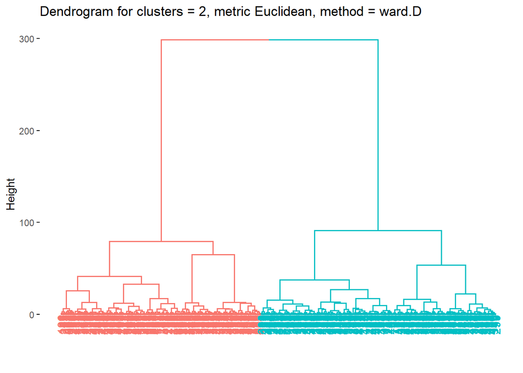

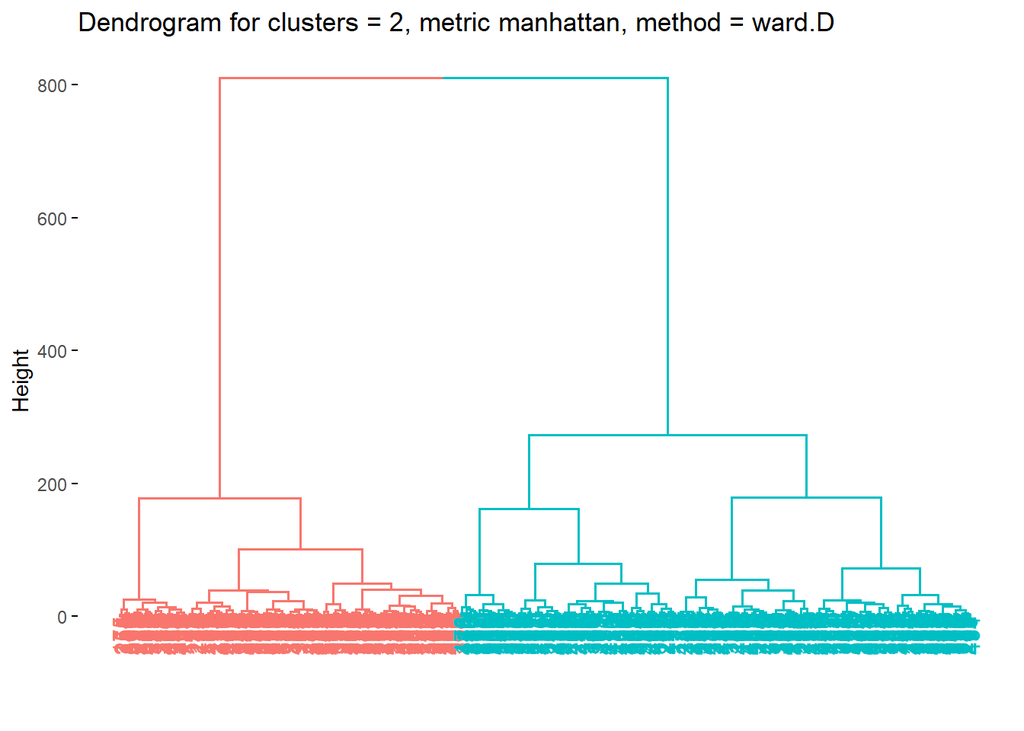

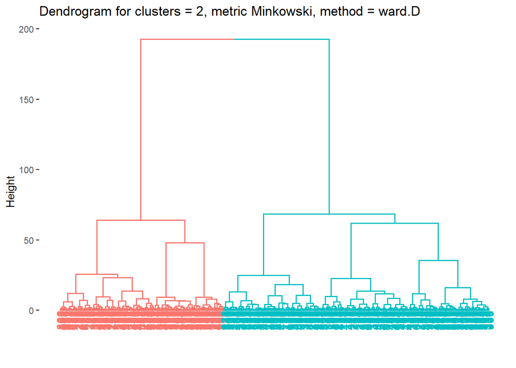

Widzimy, ze w przypadku **metryki Euklidesowej**, zbior danych zostal podzielony prawie na identyczne grupy ze wzgledu na liczbe graczy.  
W przypadku metryki **manhattan** oraz **Minkowskiego** widac skosnosc prawostronna.  
Rowniez widac, ze **metryka** wplywa istotnie na “postac” klastrow.  
Dalej beda przedstawione dendrogramy dla liczby skupien = 3.

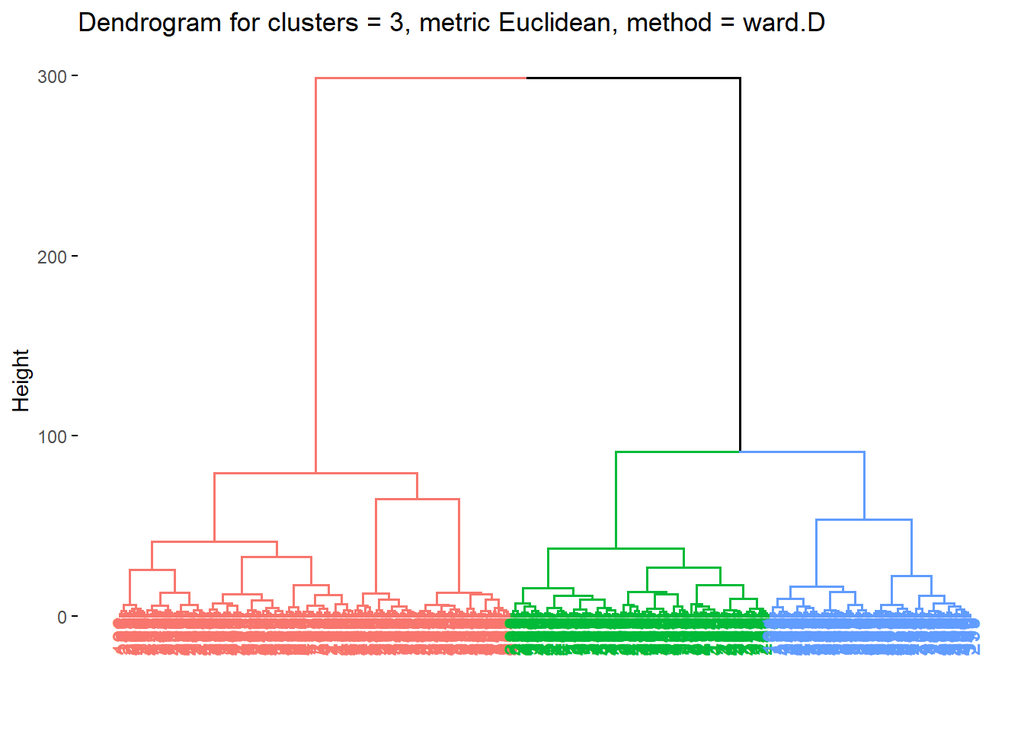

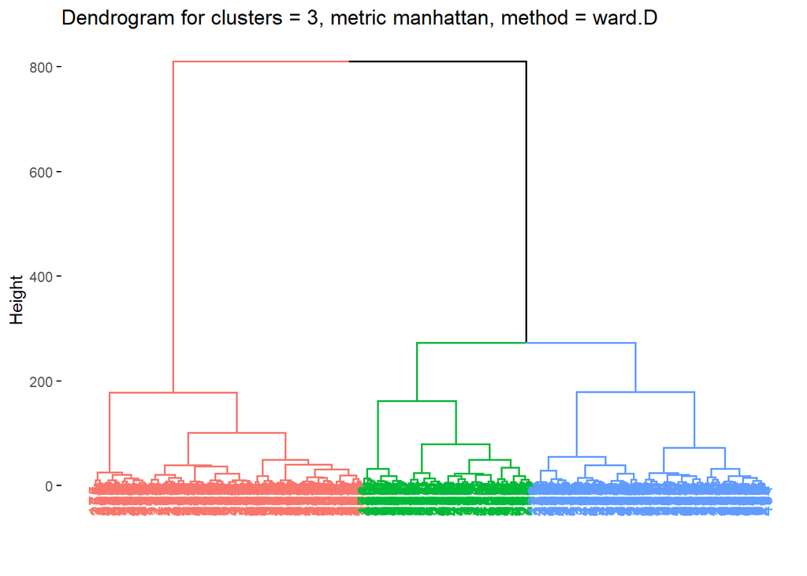

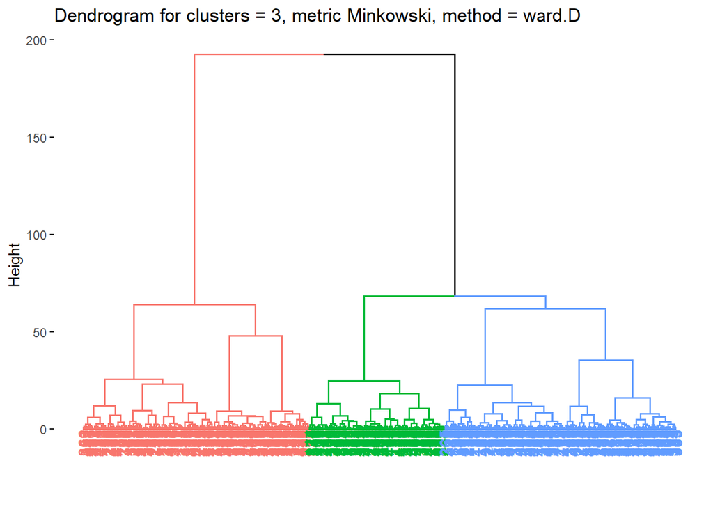

Metryka **manhattan** podzielila zbior danych mniej wiecej po rowno, co odzwierciedla tablica. (optymalna wartosc **indeksu G1**)

## **OPTYMALNA LICZBA SKUPIEN dla metody hierarchicznej, metoda “average” oraz “complete”**

Teraz zobaczymy, czy liczba skupien zmienia sie w zaleznosci od metody “aglomeracji”.

Dla metody **average**, metryka **Euklidesa**.

```
##    index G1   index G2    index S  index G3
## 2  70.47991  0.7551559 0.36882392 0.3274708
## 3  41.32617  0.7449525 0.21255918 0.3354640
## 4  30.69413  0.7448193 0.15222210 0.3354375
## 5  28.01446  0.6363648 0.06061270 0.3305465
## 6  78.74367 -1.3516994 0.12547344 0.3794328
## 7  65.72967 -1.3513519 0.10643286 0.3789215
## 8  57.37963 -1.3515526 0.07400952 0.3777814
## 9  51.35812 -1.3707829 0.05734119 0.3719260
## 10 71.59925 -1.4608817 0.06130183 0.3845561
## 11 65.04537 -1.4611981 0.05359611 0.3845155
## 12 57.19353 -1.4725280 0.05359095 0.3834870
## 13 60.75528 -1.6303351 0.06953625 0.3727134
## 14 56.34740 -1.6311513 0.06907772 0.3726614
## 15 69.11365 -2.4339208 0.10132463 0.3258169
```

[output cut: 35 more lines]

Dla metody **average**, metryka **manhattan**.

```
##     index G1   index G2    index S  index G3
## 2  197.62959  0.6122981 0.32608707 0.2914949
## 3  100.25896  0.6120163 0.26066867 0.2914264
## 4  151.42489 -1.3558535 0.21171026 0.3214942
## 5  116.47079 -1.3594318 0.19291878 0.3164038
## 6  151.15786 -1.5230967 0.15399368 0.3546956
## 7  126.86418 -1.5344217 0.13238859 0.3532452
## 8  112.07646 -1.5854674 0.12136134 0.3485427
## 9  107.22282 -1.5946982 0.11871095 0.3477335
## 10  96.10132 -1.6257893 0.09419082 0.3454928
## 11 101.51997 -1.8864861 0.11252628 0.3595820
## 12  93.27496 -1.8874216 0.10204033 0.3595233
## 13  86.74331 -1.8885726 0.10157369 0.3594593
## 14  80.86598 -1.8891338 0.09696909 0.3594368
## 15  79.19055 -1.9067429 0.08027885 0.3587362
```

[output cut: 35 more lines]

Dla metody **average**, metryka **Minkowskiego**.

```
##     index G1   index G2    index S  index G3
## 2  257.87083 -2.2099788 0.27045345 0.3249248
## 3  130.26654 -2.1140843 0.17906641 0.3231093
## 4   88.52742 -2.1056512 0.14947553 0.3229451
## 5  100.82803 -1.4444452 0.10489335 0.3537804
## 6   80.74305 -1.3793081 0.09331345 0.3471834
## 7  107.27016 -1.3735514 0.10969735 0.3960289
## 8   99.32754 -1.3778350 0.09938580 0.3947588
## 9   88.43161 -1.3782227 0.08436845 0.3946589
## 10  81.97034 -1.3902006 0.08270613 0.3930171
## 11  75.74820 -1.3950868 0.07578156 0.3924104
## 12  69.19169 -1.3954641 0.07542788 0.3923708
## 13  67.10113 -1.7602017 0.08966266 0.3791891
## 14  60.01213 -1.7808915 0.09188414 0.3779305
## 15  56.58473 -1.7881055 0.07460798 0.3775486
```

[output cut: 35 more lines]

Dla metody **complete**, metryka **Euklidesa**.

```
##     index G1   index G2    index S  index G3
## 2  402.05680 -1.3938827 0.25704211 0.3441036
## 3  163.23342 -1.4077844 0.18262108 0.3582778
## 4  156.44529 -1.7596007 0.11888283 0.3671352
## 5  172.33731 -1.7921424 0.11547965 0.3766754
## 6  139.35055 -2.3378966 0.09644444 0.3929522
## 7  114.14839 -2.3499403 0.09404326 0.4027073
## 8  101.54558 -2.4377975 0.09127991 0.4218127
## 9   89.01570  0.5811191 0.09252189 0.4038660
## 10  79.06791  0.5974959 0.09495707 0.4036207
## 11  71.33271  0.6008566 0.08211628 0.4096973
## 12  68.88380  0.6212916 0.07165734 0.4301047
## 13  70.43506  0.6452016 0.08073247 0.4225831
## 14  66.80118  0.6593928 0.07902107 0.4264879
## 15  66.50121  0.6672780 0.07667665 0.4442226
```

[output cut: 35 more lines]

Dla metody **complete**, metryka **manhattan**.

```
##     index G1   index G2    index S  index G3
## 2  357.99561 -1.6106443 0.30400946 0.2904655
## 3  236.71630 -1.3328146 0.19887219 0.3368027
## 4  226.29920 -1.5040791 0.12011061 0.3734371
## 5  181.80131 -1.5224290 0.10803505 0.3736726
## 6  149.83208 -1.9910161 0.10619558 0.3705800
## 7  136.92117 -2.0186711 0.11081467 0.3956310
## 8  130.66296  0.5991564 0.08838704 0.3980004
## 9  122.12178  0.6301617 0.09336018 0.3992212
## 10 112.03697  0.6639197 0.09967766 0.3831601
## 11 114.36294  0.6798534 0.10769519 0.3950437
## 12 104.22878  0.6925009 0.10502853 0.4250636
## 13  96.05834  0.6954590 0.10144612 0.4247244
## 14  93.72274  0.7123576 0.10446985 0.4154720
## 15  87.13908  0.7187104 0.10448296 0.4117159
```

[output cut: 35 more lines]

Dla metody **complete**, metryka **Minkowskiego**.

```
##     index G1   index G2    index S  index G3
## 2  166.38515 -1.7969634 0.16962076 0.3381583
## 3  105.65380 -1.5992344 0.13975247 0.3336048
## 4  123.65419 -1.6315323 0.13214825 0.3662999
## 5  131.17678 -1.9292682 0.12800369 0.3918263
## 6  112.37727 -2.0498754 0.11477745 0.3966555
## 7   96.24737  0.5913001 0.11724763 0.3740500
## 8   80.99619  0.6025865 0.09449013 0.3992529
## 9   70.65116  0.6114789 0.09223763 0.4014829
## 10  67.14497  0.6245727 0.09200358 0.4130575
## 11  69.88560  0.6483115 0.08952767 0.4188992
## 12  63.93955  0.6544787 0.08781880 0.4165147
## 13  60.11801  0.6692437 0.08880434 0.4129970
## 14  61.41784  0.6839064 0.09364946 0.4117125
## 15  56.33272  0.6951353 0.08741871 0.4089216
```

[output cut: 35 more lines]

## **GRAFICZNA PREZENTACJA WYNIKOW dla metody hierarchicznej, metoda “average” oraz “complete”**

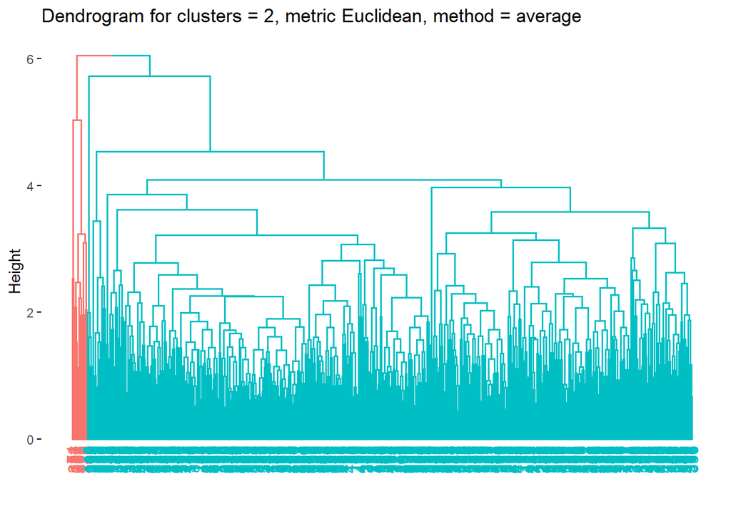

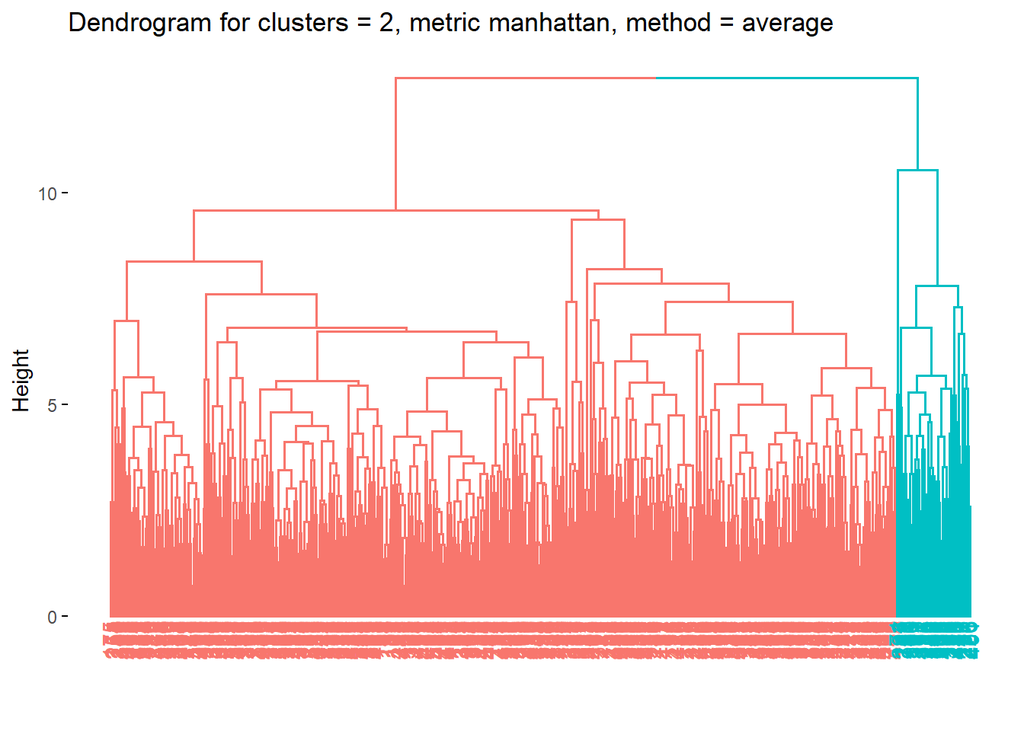

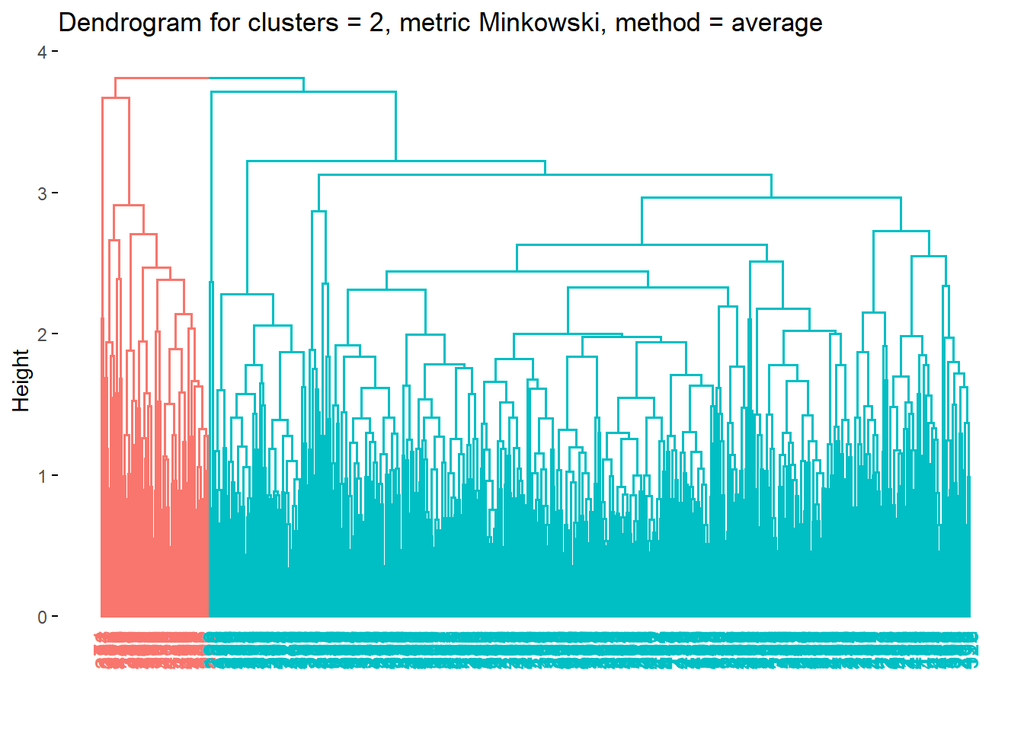

Widzimy, ze w porownaniu do metody **“ward.D”**, metoda **average** dzieli zbior danych mocno “jednostronnie”, to znaczy widac jedna grupe o malej liczbie graczy. Metryka **Euklides** i **“Minkowskiego”** pokazuje prawie identyczne wyniki, w przypadku drugiej metryki grupa jest nieco wieksza.  
Metryka **manhattan** “odzwierciedla” wyniki dla poprzednich metryk.  
Dendrogramy dla metody **complete**.

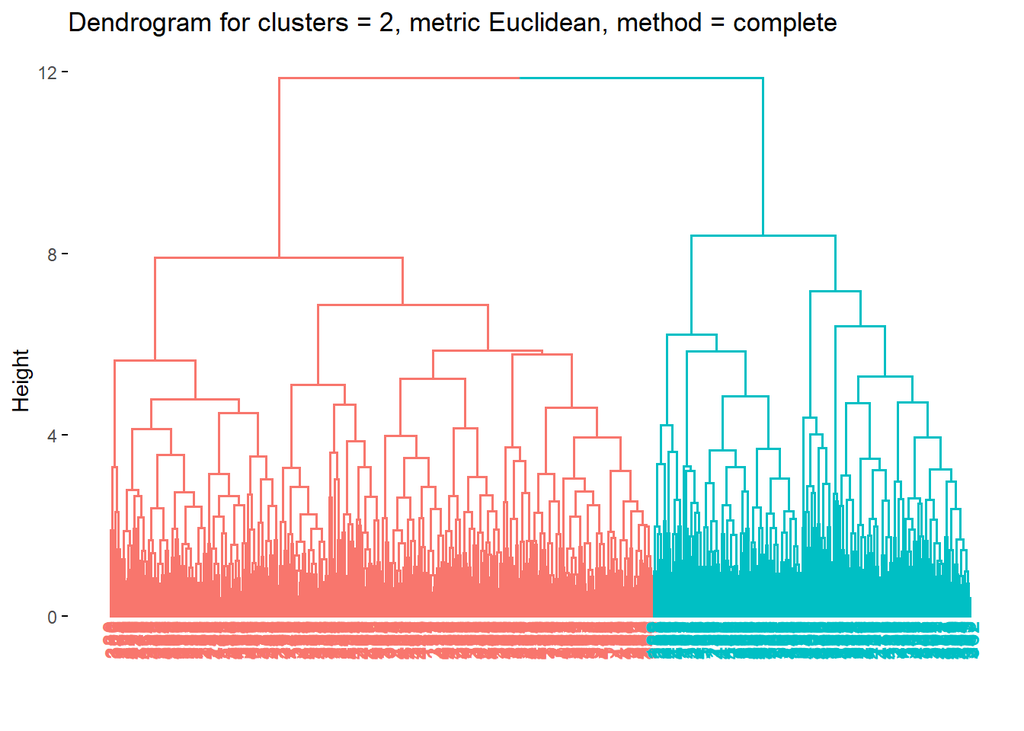

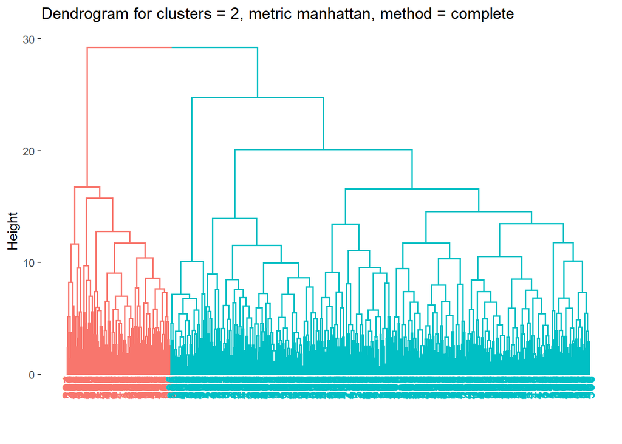

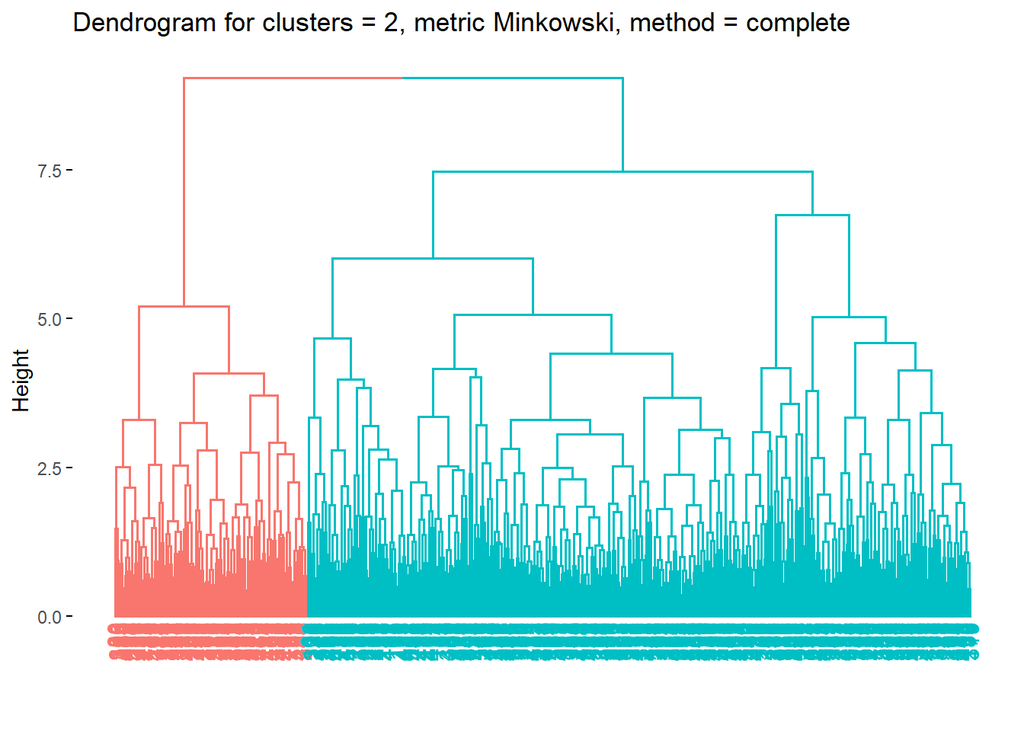

W przeciwienstwie do metody **average**, metoda **complete** ma podobne wyniki dla metryk **manhattan** i **Minkowskiego**.  
Natomiast metryka **Euklidesowa** odzwierciedla wyniki poprzednich metryk.  
Widzimy podobienstwo metod **average** i **complete** w podziale zbioru danych na mniejsza i wieksza grupe.

W przypadku metody **complete** widzimy, ze istotnym jest sprawdzic liczbe skupien = 3. Na dendrogramach widac mozliwy podzial na wieksza liczbe skupien.

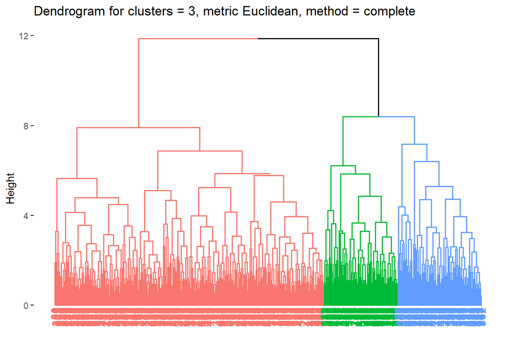

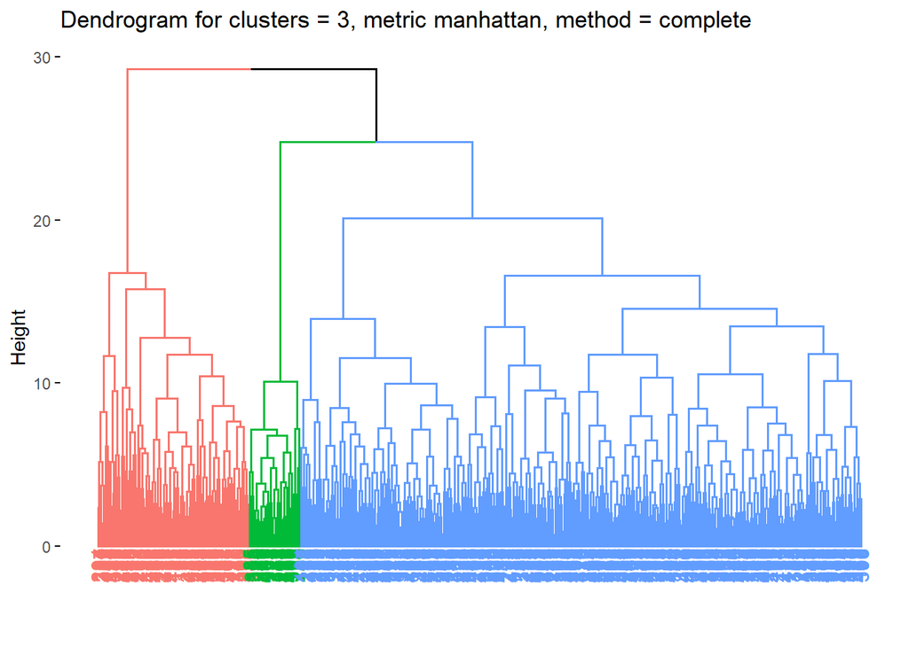

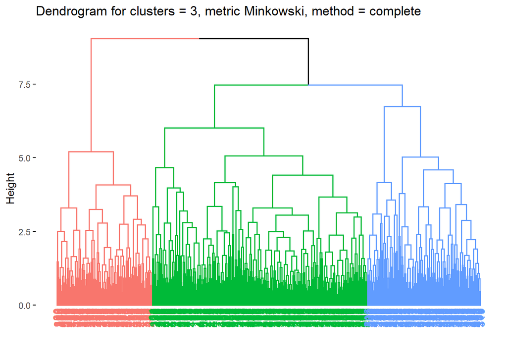

Widzimy, ze chociaz w przypadku metryk **Euklidesa** i **manhattan** roznica nie jest az tak spora w porownaniu do liczby skupien = 2, natomiast w przypadku metryki **Minkowskiego** zbior danych zostal podzielony na 3 charakterystyczne klastry.  
Dla metody **average** proba zwiekszenia liczby skupien nie powiodla sie, wyniki byly znikome i nie maja istotnego sensu do prezentacji.

##** WYBOR OPTYMALNYCH GRUPOWAN dla metody podzialowej oraz hierarchicznej**

Dla metody **k-srednich** powstaje wybor pomiedzy 2, 3 oraz 4 grupami. Wybieramy metryke **Euklidesa**. Porownywac bedziemy na bazie **indeksu CH** oraz **entropii** poprzez funkcje **cluster.stats**. GRUPOWANIE z **wiekszym** CH i **mniejsza** entropia jest lepsze.

```
## [1] "235.035045632436"  "0.693028832695866" "GRUP = 2"
```

```
## [1] "181.612397414864" "1.06717200871544" "GRUP = 3"
```

```
## [1] "159.711087067047" "1.36448372697131" "GRUP = 4"
```

Widzimy, ze dla liczby podzialow = 2 sa najlepsze wyniki. Ostatecznie dla metody **k-srednich** wybieramy podzial na 2 grupy.

Dla metody **k-medoid** powstaje wybor rowniez pomiedzy 2, 3 oraz 4 podzialami, ale w przypadku medoid jest jeszcze podzial na metryki.

```
## [1] "206.211161466772" "0.59725971483182" "GRUP = 2"         "Euklides"
```

```
## [1] "163.250022448714"  "0.919584271943869" "GRUP = 3"
## [4] "Euklides"
```

```
## [1] "140.099757796203" "1.2520109059512"  "GRUP = 4"         "Euklides"
```

```
## [1] " "
```

```
## [1] "262.119581511511"  "0.629167037824939" "GRUP = 2"
## [4] "manhattan"
```

```
## [1] "222.183938409855" "1.02002848583859" "GRUP = 3"         "manhattan"
```

```
## [1] "191.816176435608" "1.33800177439236" "GRUP = 4"         "manhattan"
```

Dla metody **ward.D** wyniki dla liczby 2 oraz 3 sa nastepujace.

```
## [1] "222.236868868094" "0.68988179043237" "GRUP = 2"         "Euklides"
## [5] "method = ward.D"
```

```
## [1] "263.220191429568"  "0.673011667009257" "GRUP = 2"
## [4] "manhattan"         "mehtod = ward.D"
```

```
## [1] "169.339864377488" "0.66443944668544" "GRUP = 2"         "Minkowski"
## [5] "method = ward.D"
```

```
## [1] " "
```

```
## [1] "150.581605933733" "1.06024519649721" "GRUP = 3"         "Euklides"
## [5] "method = ward.D"
```

```
## [1] "193.968423563372" "1.08177110480718" "GRUP = 3"         "manhattan"
## [5] "method = ward.D"
```

```
## [1] "118.078364243626" "1.07234153945379" "GRUP = 3"         "Minkowski"
## [5] "method = ward.D"
```

Widzimy, ze najlepsze wynik jest w przypadku podzialu na 2 liczby skupien, metryka **manhattan**.

Dla metod **average** oraz **complete**, liczba skupien = 2, dla poszczegolnych metryk wyniki sa nastepujace.

```
## [1] "217.510427627909"  "0.658545013538294" "GRUP = 2"
## [4] "Euklides"          "method = complete"
```

```
## [1] "205.976553597526"  "0.49772488796441"  "GRUP = 2"
## [4] "manhattan"         "method = complete"
```

```
## [1] "118.137815008391"  "0.533163840737299" "GRUP = 2"
## [4] "Minkowski"         "method = complete"
```

```
## [1] " "
```

```
## [1] "44.1946216776028"  "0.116906849137531" "GRUP = 2"
## [4] "Euklides"          "method=average"
```

```
## [1] "126.196026545348"  "0.294455073198321" "GRUP = 2"
## [4] "manhattan"         "method=average"
```

```
## [1] "117.632826954892"  "0.376770161256437" "GRUP = 2"
## [4] "Minkowski"         "method=average"
```

```
## [1] " "
```

```
## [1] "129.680319230876"  "0.913754656124091" "GRUP = 3"
## [4] "Euklides"          "method = complete"
```

```
## [1] "163.748413896207"  "0.728896233830293" "GRUP = 3"
## [4] "manhattan"         "method = complete"
```

```
## [1] "114.591563621572"  "1.03245036867714"  "GRUP = 3"
## [4] "Minkowski"         "method = complete"
```

Widzimy, ze optymalna liczba skupien zostala osiagnieta w przypadku **metody complete** dla liczby skupien = 2 **metryka Euklidesa**, ale **entropia** jest mniejsza dla metryki **manhattan** wiec jednoznacznie stwierdzic, ktory z podzialow jest lepszy jest ciezko.

##**WNIOSKI**

**Celem projketu** bylo sprawdzenie zachowania roznych metod grupowania na danych “realnych”. Optymalna liczba podzialow/skupien ze wzgledu na wyniki **indeksow G1,G2,G3 oraz S** byla ustalona przy pomocy **indeksu CH** oraz **entropii** i wyniosla 2 dla **metod hierarchicznych**.  
W przypadku **metod podzialowych** indeksy nie spisaly sie dobrze, raczej ich wklad w analize byl znikomy.

Zauwazmy, ze metryka **Minkowskiego** jest tak naprawde metryka **Euklidesa** o wiekszej potedze. To tlumaczy dlaczego wyniki sa gorsze w przypadku owej metryki. Natomiast w przypadku metryki **manhattan** odległość dwóch punktów w tej metryce to suma wartości bezwzględnych różnic ich współrzędnych, co wskazuje, ze zmniejszenie potegi we wzorze do obliczania odleglosci moze powodowac lepszy effekt koncowy obliczen. Tylko w jednym przypadku metody **hierarchicznej** typu **complete** dla 2 klastrow metryka **Euklidesa** miala lepszy wynik od **manhattan** ale tylko o 11 jednostek, co tak naprawde jest znikome.

Chociaz, wedlug obliczen dla metody **hierarchicznej** kazdego typu najlepsze wyniki osiagniete w przypadku 2 skupien, wizualnie najlepiej wyglada podzial na 3 klastry metoda **complete** w metryce **Minkowskiego**, co kieruje na mysl, ze nie zawsze wyniki “suchych” obliczen sa najlepszymi podstawami dla wnioskow koncowych.

##**DZIEKUJE ZA UWAGE**